# Data Science Capstone - Milestone Report

Shouman Das

February 23, 2017

# Executive Summary

In this capstone project, we will build a predictive text model based on algorithms in natural language processing. Given a word in a text, our model will predict the next word. For our analysis and models, we use the data from a corpus called HC corpora(http://www.corpora.heliohost.org/). See the readme file at http://www.corpora.heliohost.org/aboutcorpus.html for details on the corpora available.

This report describes a exploratory analysis on the dataset and summarizes our future work to build the predictive text model.

# Getting the Data

First we download and extract the zip file contained at [Capstone Data](https://d396qusza40orc.cloudfront.net/dsscapstone/dataset/Coursera-SwiftKey.zip). The dataset contains three kinds of text documents: News, Blogs, Twitter posts. They are provided in 4 different languages: German, English, Finnis, Russian. In our capstone project we will only be concerned with the English Dataset. Now we load the data in Rstudio.

```r
setwd("~/Downloads/Data/Capstone/final/en_US")
blogs <- readLines("en_US.blogs.txt", encoding = "UTF-8", skipNul = TRUE)
news <- readLines("en_US.news.txt", encoding = "UTF-8", skipNul = TRUE)
twitter <- readLines("en_US.twitter.txt", encoding = "UTF-8", skipNul = TRUE)
```

Now we make a basic summary of our text documents i.e. number of lines, words, file sizes.

```r
library(stringi)

# Number of words
blogs.wd <- stri_count_words(blogs)
news.wd <- stri_count_words(news)
twitter.wd <- stri_count_words(twitter)

# Calculate size
blogs.sz = file.info("en_US.blogs.txt")$size / 2^20
news.sz = file.info("en_US.news.txt")$size / 2^20
twitter.sz = file.info("en_US.twitter.txt")$size / 2^20

# summarize the data
data.frame(source = c("blogs", "news", "twitter"),
           num.lines = c(length(blogs),length(news), length(twitter)),
           num.words = c(sum(blogs.wd), sum(news.wd), sum(twitter.wd)),
           file.size.MB = c(blogs.sz, news.sz, twitter.sz)
)
```

```
##    source num.lines num.words file.size.MB
## 1   blogs    899288  37546246     200.4242
## 2    news   1010242  34762395     196.2775
## 3 twitter   2360148  30093410     159.3641
```

# Sampling and Preprocessing

Since our data is huge, we will sample the data before starting our exploratory analysis. We will consider 1% of our whole data.

```r
options(mc.cores=1)

library(tm)
set.seed(1234)
Sample <- c(sample(blogs, length(blogs)*.01),
            sample(news, length(news)*.01),
            sample(twitter, length(twitter)*.01))

# create myCorpus and preprocessing
corpus <- VCorpus(VectorSource(Sample))
corpus <- tm_map(corpus, PlainTextDocument)

toSpace <- content_transformer(function(x, pattern) gsub(pattern, " ", x))


# Removing URLs
corpus <- tm_map(corpus, toSpace, "(f|ht)tp(s?)://(.*)[.][a-z]+")

corpus <- tm_map(corpus, toSpace, "@[^\\s]+")
corpus <- tm_map(corpus, content_transformer(tolower))
corpus <- tm_map(corpus, removePunctuation)
corpus <- tm_map(corpus, removeNumbers)
corpus <- tm_map(corpus, stripWhitespace)
corpus <- tm_map(corpus, PlainTextDocument)
corpus <- VCorpus(VectorSource(corpus))
```

# Exploratory Analysis

Now we can start our exploratory analysis. We will find out the most frequent unigram, bigram, trigram in our corpus.

```r
library(RWeka)
library(ggplot2)

get_freq <- function(tdm) {
  freq <- sort(rowSums(as.matrix(tdm)), decreasing = TRUE)
  return(data.frame(word = names(freq), freq = freq))
}

# unigramTokenizer <- function(x) NGramTokenizer(x, Weka_control(min = 1, max = 1))
# bigramTokenizer <- function(x) NGramTokenizer(x, Weka_control(min = 2, max = 2))
# trigramTokenizer <- function(x) NGramTokenizer(x, Weka_control(min = 3, max = 3))

bigramTokenizer <-
  function(x)
    unlist(lapply(ngrams(words(x), 2), paste, collapse = " "), use.names = FALSE)
trigramTokenizer <-
  function(x)
    unlist(lapply(ngrams(words(x), 3), paste, collapse = " "), use.names = FALSE)

makePlot <- function(data, label) {
  ggplot(data[1:25,], aes(reorder(word, -freq), freq)) +
         labs(x = label, y = "Frequency") +
         theme(axis.text.x = element_text(angle = 70, size = 15, hjust = 1)) +
         geom_bar(stat = "identity", fill = I("blue1"))
}

unigram_freq <- get_freq(removeSparseTerms(
    TermDocumentMatrix(corpus), 0.999))

bigram_freq <- get_freq(removeSparseTerms(
    TermDocumentMatrix(corpus, control = list(tokenize = bigramTokenizer)), 0.999))

trigram_freq <- get_freq(removeSparseTerms(
    TermDocumentMatrix(corpus, control = list(tokenize = trigramTokenizer)), 0.999))
```

Now we can have a look at the head of unigrams and make a histogram with the 25 most common unigrams.

```r
head(unigram_freq, 10)
```

```
##      word  freq
## the   the 47923
## and   and 24307
## for   for 10812
## that that 10410
## you   you  9515
## with with  7197
## was   was  6407
## this this  5456
## have have  5439
## but   but  4897
```

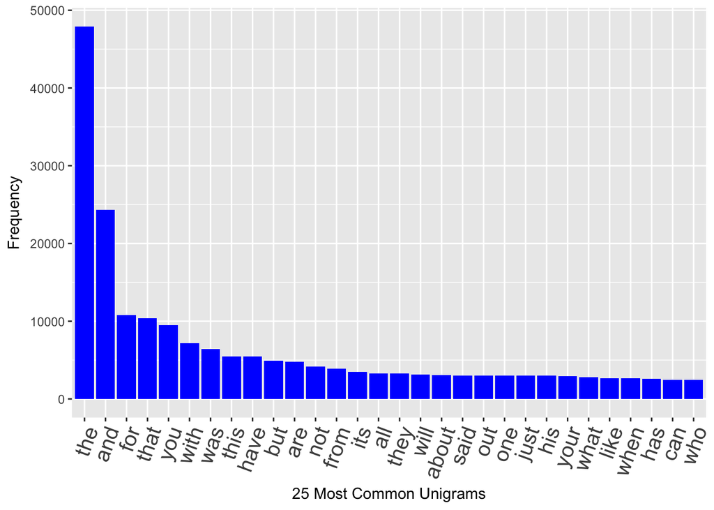

```r
makePlot(unigram_freq, "25 Most Common Unigrams")
```

We can also have similar plots for bigrams and trigrams.

```r
head(bigram_freq, 10)
```

```
##              word freq
## of the     of the 4261
## in the     in the 4147
## to the     to the 2238
## for the   for the 1989
## on the     on the 1920
## to be       to be 1592
## at the     at the 1496
## and the   and the 1237
## in a         in a 1185
## with the with the 1060
```

[figure not shown]

```r
makePlot(bigram_freq, "25 Most Common Unigrams")
```

```r
head(trigram_freq, 10)
```

```
##                          word freq
## one of the         one of the  358
## a lot of             a lot of  313
## thanks for the thanks for the  242
## to be a               to be a  192
## going to be       going to be  178
## it was a             it was a  150
## out of the         out of the  146
## as well as         as well as  145
## some of the       some of the  144
## i want to           i want to  138
```

[figure not shown]

```r
makePlot(trigram_freq, "25 Most Common Unigrams")
```

```r
saveRDS(unigram_freq, 'unigram_freq.rds')
saveRDS(bigram_freq,'bigram_freq.rds')
saveRDS(trigram_freq,'trigram_freq.rds')
```

## Interesting Observations

- While running our code, most of the time is consumed by loading and reading the data.
- In our histograms, we did not remove stopwords, since stopwords are an important aspect of any language and we will include the stopwords when we build our predictive text model.

# Future work

Our future work will be to implement our markov chain algorithm to create a predictive text model. After making our model we will deploy it as a shiny app, where a user can write something in english and our model will predict the next 2/3 words.